# Using Neural Networks to Gauge Reddit Comments About Elon Musk

As we all know Elon Musk likes to be talked about. I remember, when I first started using reddit around 2016, Elon Musk was a literal god. He could do no wrong. He was going to save humanity. As we all know now, that opinion has changed a bit. I was interested in doing an analysis on how the opinion changed.

For my attempt to train a neural network, I had to develop a training dataset for this purpose. For that I required reddit comments. This was not too difficult - it is available [here](https://academictorrents.com/details/1614740ac8c94505e4ecb9d88be8bed7b6afddd4). When I downloaded the dataset, it was only updated till 2022. For our discussions here, I have only chosen two subreddits - r/technology and r/futurology. I had also downloaded comments from r/realtesla and r/elonmusk, because I thought one overtly critical and one overtly supportive subreddits will give some sanity checks.

From the comments, I only collected comments mentioning "Elon Musk" or "Elon" or "Musk" (case sensitive). I saved all of them into a SQL database.

```python
import datetime
import sqlite3
import matplotlib.pyplot as plt
import time
import numpy as np
import math
from tqdm import tqdm
from huggingface_hub import PyTorchModelHubMixin
%config InlineBackend.figure_format = 'svg'
plt.rc('text', usetex=True)
plt.rc('font', family='serif')
```

```python
connection = sqlite3.connect("/Users/varghese/VARGHESE/transformers/reddit_technology_futurology.db")
cursor = connection.cursor()
```

## Closer look at comments.

Let us see how many comments where made in each month. Remember each comment is a mention of "Elon Musk/(...)" We systematically count the number of comments present in each month starting from 1/1/2007 to 31/12/2022 and plot to see how interest in Elon Musk evolved over time.

```python
m31=[1,3,5,7,8,10,12] # These are all the months which as 31 days.

year_month_ncom = {}

for year in range(2007,2023): #
    for month in range(1,13):
        if(month in m31):
            string = "01/{}/{}".format(month,year)
            from_after=int(time.mktime(datetime.datetime.strptime(string,"%d/%m/%Y").timetuple()))
            string = "31/{}/{}".format(month,year)
            from_before=int(time.mktime(datetime.datetime.strptime(string,"%d/%m/%Y").replace(hour=23, minute=59, second=59, microsecond=999999).timetuple()))
        elif(month == 2):
            if(year in [2008,2012,2016,2020]):
                string = "01/{}/{}".format(month,year)
                from_after=int(time.mktime(datetime.datetime.strptime(string,"%d/%m/%Y").timetuple()))
                string = "29/{}/{}".format(month,year)
                from_before=int(time.mktime(datetime.datetime.strptime(string,"%d/%m/%Y").replace(hour=23, minute=59, second=59, microsecond=999999).timetuple()))
            else:
                string = "01/{}/{}".format(month,year)
                from_after=int(time.mktime(datetime.datetime.strptime(string,"%d/%m/%Y").timetuple()))
                string = "28/{}/{}".format(month,year)
                from_before=int(time.mktime(datetime.datetime.strptime(string,"%d/%m/%Y").replace(hour=23, minute=59, second=59, microsecond=999999).timetuple()))
        else:
            string = "01/{}/{}".format(month,year)
            from_after=int(time.mktime(datetime.datetime.strptime(string,"%d/%m/%Y").timetuple()))
            string = "30/{}/{}".format(month,year)
            from_before=int(time.mktime(datetime.datetime.strptime(string,"%d/%m/%Y").replace(hour=23, minute=59, second=59, microsecond=999999).timetuple()))

        query = "SELECT * FROM  comments where comments.created_date <= {} and comments.created_date >= {}".format(from_before,from_after)
        result = cursor.execute(query)
        ncom = len(result.fetchall())
        year_month_ncom[datetime.datetime(year,month,1)]=ncom
```

The number of comments mentioning Elon Musk increases by multiple orders of magnitudes over the years.

```python
fig,ax = plt.subplots(1,1)
ax.plot(year_month_ncom.keys(),year_month_ncom.values(),'o')

ax.set_yscale('log')

ax.set_xlabel("Year")
ax.set_ylabel("Number of Comments")
```

[figure not shown]

We are not going to be doing sentiment analysis. To the best of my knowledge, sentiment analysis requires one to have a training dataset in which one has marked which comments corresponds to which sentiment. This was my initial approach. I tried to create a dataset in which I marked comments as positive, negative and neutral. However, this method was tedious, and error prone. Quite a few comments are not easily classifiable. Also, many comments talk about many other topics.

I abandoned this approach to build a text generation model. This has the advantage that I don't have to manually generate the dataset. I can train the model to predict the next token. This way, the model should be able to generate a text which is an average of the all the comments. From these generated texts, I should be able to gauge the emotion.

# Text-Generation Model

For text generation, we copy all the comments to a text file and use a gpt-2 tokenizer from HugginFace to convert the comments into tokens. I won't demonstrate it here and one can checkout Andrej Karpathy's [video](https://www.youtube.com/watch?v=7xTGNNLPyMI) to learn more. To summarize, I have a text file in which I have stored all the comments as tokens. Essentially, all comments have been appended to a single text file and this has been converted to tokens which are numbers between $[0,n_{vocab}]$, where $n_{vocab}=50257$.

To train text generation, our objective is - given $n$ tokens, predict the $n+1$'th token. Let us describe a transformer based neural network for this.

A sample of text file which needs to go through the transformer based model can be represented by $$\vec{t} = \{w_1,w_2,\ldots,w_n\}$$ where each $w_i\in[0,n_{vocab}]$.

First let us load the data and take a look

```python
with open("/Users/varghese/VARGHESE/transformers/tech_future_file_tokenized_2016_09_30","r") as f:
    all_text=f.readlines()

text=all_text[0].split()
text=list(map(int,text))
```

We will import gpt-2 tokenizer from HugginFace transformers directory.

```python
from transformers import AutoTokenizer
tokenizer = AutoTokenizer.from_pretrained('gpt2')
vocab_size = tokenizer.vocab_size + 1
```

```python
print(vocab_size)
```

```
50258
```

A random piece of text can be decoded as such

```python
begin = np.random.randint(1000)
end = begin + np.random.randint(40)
sample=text[begin:end]
print(sample)
print(tokenizer.decode(sample))
```

```
[11, 644, 262, 1772, 10143, 284, 3465, 287, 477, 286, 465, 3781, 318, 326, 262, 720, 1065, 11, 830, 583, 14896, 2756, 7621, 318, 1912, 319, 1459, 357, 494, 25, 845, 1468]
, what the author fails to note in all of his analysis is that the $12,000 per pound price tag is based on current (ie: very old
```

## Embedding Layer

First thing we do with this vector is to pass this through an embedding layer. An embedding layer is basically a lower dimensional representation of the words. Currently, the tokens are in a $n_{vocab}$ dimensional space, there is also no correlation between the words in this $n_{vocab}$ dimensional space. Although some words are more correlated than others. We will let our network figure out the correlatios, but for now, we will just use a random weight matrix for embedding. Technically, we can convert a token into a one-hot representation and run it through a $n_{embedding}\times n_{vocab}$ matrix, but Pytorch has the tools for that.

```python
import torch
from torch import nn
N_EMBEDDING = 128
embedding_layer = nn.Embedding(vocab_size,N_EMBEDDING)
```

```python
sample=torch.tensor(sample)
```

```python
sample.shape
```

```
torch.Size([32])
```

```python
embedding=embedding_layer(sample)
print(embedding.shape)
```

```
torch.Size([32, 128])
```

So the tokenized sample text has been converted to a array of 128 dimensional vectors. So, now the text is represented as $$\vec{t} = \{ \vec{w}_1,\vec{w}_2,\ldots,\vec{w}_n\}$$ where each $\vec{w}_i$ is a $n_{embedding}$ dimensional vector.

## Position encoding

Because transformers, unlike LSTM/RNN etc, processes all the input vectors of the text simultaneously, we need to add some information which incorporates the sequence into this text. Check this [video](https://www.youtube.com/watch?v=dichIcUZfOw) for more information.

So every even dimension of the embedding vectors gets added with a $\sin$ function of wavelength $2\pi$ to $2\pi. 10000$ and a $\cos$ function for every odd dimension. Check the [implementation](http://nlp.seas.harvard.edu/annotated-transformer/#positional-encoding) below. They also add a dropout layer to this for some reason. Here `d_model` is $n_{embedding}$.

```python
class PositionalEncoding(nn.Module):
    "Implement the PE function."

    def __init__(self, max_len, d_model, dropout=0.1):
        super(PositionalEncoding, self).__init__()
        self.dropout = nn.Dropout(p=dropout)

        # Compute the positional encodings once in log space.
        pe = torch.zeros(max_len, d_model)
        position = torch.arange(0, max_len).unsqueeze(1)
        div_term = torch.exp(
            torch.arange(0, d_model, 2) * -(math.log(10000.0) / d_model)
        )
        pe[:, 0::2] = torch.sin(position * div_term)
        pe[:, 1::2] = torch.cos(position * div_term)
        pe = pe.unsqueeze(0)
        self.register_buffer("pe", pe)

    def forward(self, x):
        x = x + self.pe[:, : x.size(1)].requires_grad_(False)
        return self.dropout(x)
```

We need to reshape to account for the batch dimension as well.

```python
embedding=embedding.reshape(1,embedding.size(0),embedding.size(1))

PE = PositionalEncoding(256,N_EMBEDDING)
PE(embedding).shape
```

```
torch.Size([1, 32, 128])
```

## Transformer Decoder Layer

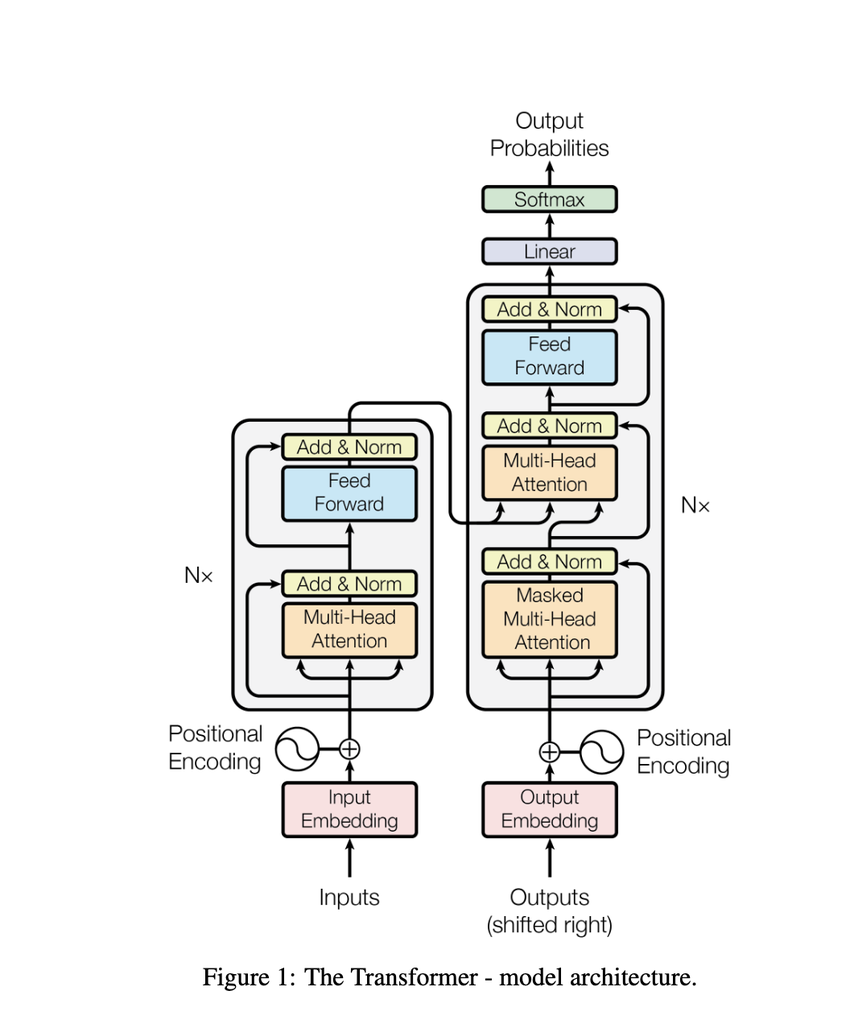

In the [attention paper](https://arxiv.org/pdf/1706.03762), they have used a encoder-decoder architecture. This model was developed for machine translation. In this we will use just the decoder architecture. Pytorch provides this. If we look at the Pytorch [Module](https://pytorch.org/docs/stable/generated/torch.nn.TransformerDecoderLayer.html#torch.nn.TransformerDecoderLayer) for this, we have `nn.TransformerDecoderLayer`.

The definition of this class is

`torch.nn.TransformerDecoderLayer(d_model, nhead, dim_feedforward=2048, dropout=0.1, activation=<function relu>, layer_norm_eps=1e-05, batch_first=False, norm_first=False, bias=True, device=None, dtype=None)`

Where the parameters should be self-explanatory. `d_model` is the $n_{embedding}$, `n_head`, is the number of attention heads, `n_head` must be a factor of `d_model`. The forward function of this decoder layer required more understanding for me.

`forward(tgt, memory, tgt_mask=None, memory_mask=None, tgt_key_padding_mask=None, memory_key_padding_mask=None, tgt_is_causal=False, memory_is_causal=False)`

When you look at the image of the Decoder block, there are two attention blocks, first one being the "Masked-Multi-Head-Attention" and the second one "Multi-Head-Attention". The implementation in Pytorch follows this closely, except the first Attention is called self-attention and the second one is called Multi-Head-Attention and both are masked. And in our implementation, both blocks behave the same way as we don't have an encoder block.

Looking at the `forward` function, the `tgt` is our input (Embeddings+Positional Encoding), the `memory` is supposed to be the input from encoder, which we don't have, instead it will be the same as the input.

Now let us talk about the `tgt_mask` and `memory_mask`. Before that let us describe what attention is,

### Attention

$$ \vec{t}=\{\vec{e}_{1},\vec{e}_{2},\ldots,\vec{e}_{length}\} $$

where $$ \vec{e}_{i}\in\mathcal{\mathbb{R}}^{1\times d_{model}} $$ We first transform the embeddings into Query, Key and Values - these are just linear operations. \begin{align*} \vec{q}_{i} & =\vec{e}_{i}W^{Q};W^{Q}\in\mathbb{R}^{d_{model}\times d_{query}}\\ \vec{k}_{i} & =\vec{e}_{i}W^{K};W^{K}\in\mathbb{R}^{d_{model}\times d_{key}}\\ \vec{v}_{i} & =\vec{e}_{i}W^{V};W^{V}\in\mathbb{R}^{d_{model}\times d_{value}} \end{align*} We need $d_{query}=d_{key}$ and usually, $d_{query}=d_{key}=d_{value}=d_{model}$. In implementation we do it using a $d_{model}\times3d_{model}$ matrix and split the array into query-key-value. Now if we have multi-headed attention them we need to split these further. Suppose we have $n_{head}$'s then we split each query, key and value into $n_{head}$ parts of length $n'=\frac{d_{model}}{n_{head}}$. Now we have, for each head a set of query-key-value each of $n'$ length for each token of the sequence. This can be represented in a matrix of dimensions $length\times n_{head}\times n'$. We do a transpose and convert this into $n_{head}\times length\times n'$ matrix, as the operation we do for each head is the same. Let us consider the query and key vectors at the $i$'th location of the sequence and of the $h$'th head, $\vec{q}_{i,h}$ and $\vec{k}_{i,h}$ - they are vectors of size $1\times n'$. We take a scaled-dot product of query at the $i$'th location in the sequence and key at the $j$'th location $\frac{\vec{q}_{i,h}^{T}.\vec{k}_{j,h}}{\sqrt{n'}}$ which is a scalar. This give us an attention matrix for each head of size $length\times length$ - let us denote this as $A_{h}$. We convert this into a probability distribution along each row using a SoftMax layer. Now for each row, we do a weighted sum of the value vectors $$ \vec{o}_{i,h}=\sum_{j}A_{h}^{i,j}\vec{v}_{j,h};\vec{o}_{i,h}\in\mathbb{R}^{1\times n'} $$ Each head gives a $\vec{o}_{i,h}$ for each token in the sequence. We concatonate each of these to get a $\vec{O}_{i}\in\mathbb{R}^{1\times d_{model}}$ for each token in the sentence. Which we use for further processing. This is the multi-headed attention mechanism. So a vector of size $length\times d_{model}$ goes in and and a vector of size $length \times d_{model}$ comes out. This is what happens in the Multi-Headed-Attention blocks. Now let us look at what attention masks are.

### Attention Masks

```python
def generate_square_subsequent_mask(sz):
    mask = (torch.triu(torch.ones(sz, sz)) == 1).transpose(0, 1)
    mask = mask.float().masked_fill(mask == 0, float('-inf')).masked_fill(mask == 1, float(0.0))
    return mask
```

```python
print(generate_square_subsequent_mask(5))
```

```
tensor([[0., -inf, -inf, -inf, -inf],
        [0., 0., -inf, -inf, -inf],
        [0., 0., 0., -inf, -inf],
        [0., 0., 0., 0., -inf],
        [0., 0., 0., 0., 0.]])
```

So the model, with all the transformer blocks outputs a sequence of same length as the input sequence. So what can we compare this with? Our neural network should, given $n$ tokens, predict the $n+1$'th token. Therefore, we shift the input by a token and that is our target sequence. So we build a `DataLoader` for getting the batched training data etc.

```python
from torch.utils.data import Dataset,DataLoader,random_split, Subset
from torch.utils.data.sampler import SubsetRandomSampler

SEQUENCE_LENGTH = 128 # Maximum sequence length
N_EMBEDDING  = 512
BATCH_SIZE = 32
```

In this dataset class, for a given index $i$, we go to $i$'th position in the text and use the next `SEQUENNCE_LENGTH` tokens as our input and the shfited tokens as our target

```python
class comments_dataset(Dataset):
    def __init__(self,file):
        self.file=file
        with open(self.file,"r") as f:
            self.all_text=f.readlines()
        self.all_text=self.all_text[0].split()
        self.all_text=list(map(int, self.all_text))
    def __len__(self):
        return(len(self.all_text)-SEQUENCE_LENGTH)
    def __getitem__(self,idx):
        sample=self.all_text[idx:idx+SEQUENCE_LENGTH]
        #sample=list(map(int, sample))
        input_sample = torch.LongTensor(sample[:-1])
        target_sample = torch.LongTensor(sample[1:])
        return(input_sample,target_sample)
```

I have two datasets, one consisting of comments from before 2016 and another one consistng of comments in 2022. My idea is to compare what the neural network trained on these two networks will say about Elon Musk.

```python
dataset=comments_dataset("/Users/varghese/VARGHESE/transformers/tech_future_file_tokenized_2022_01_01")
#dataset=comments_dataset("/Users/varghese/VARGHESE/transformers/tech_future_file_tokenized_2016_09_30")
```

```python
print("We have about {} batches in our dataset".format(round(len(dataset)/32)))
```

```
We have about 209334 batches in our dataset
```

So that is a lot of batches - we will use only a fraction of these.

```python
train_validation_test_split = [0.002,0.002]

random_seed= 42
shuffle_dataset = True

dataset_size = len(dataset)
indices = list(range(dataset_size))
split_train = int(np.floor(train_validation_test_split[0] * dataset_size))
split_valid = int(np.floor(train_validation_test_split[1] * dataset_size))
    #split_test = int(np.floor(test_validation_train_split[2] * dataset_size))

#if shuffle_dataset:
np.random.seed(random_seed)
np.random.shuffle(indices)
train_indices, val_indices = indices[:split_train], indices[split_train:split_train+split_valid]

train_dataset = Subset(dataset,train_indices)
valid_dataset = Subset(dataset,val_indices)

train_loader = torch.utils.data.DataLoader(train_dataset, batch_size=BATCH_SIZE)
validation_loader = torch.utils.data.DataLoader(valid_dataset, batch_size=BATCH_SIZE)
```

```python
print("We have about {} batches in our TRAIN dataset".format(round(len(train_dataset)/32)))
print("We have about {} batches in our VALID dataset".format(round(len(valid_dataset)/32)))
```

```
We have about 419 batches in our TRAIN dataset
We have about 419 batches in our VALID dataset
```

Let us look at a sample

```python
tokenizer.decode(train_dataset[232][0])
```

```
" a way that doesn't incur the $1B penalty for doing so.It would be hard for Musk to get blocked for a TELSA pump tweet. Twitter censors very little in reality. \n\nElon is sometimes a jerk, but he doesn’t incite violence and I’d say he is very rarely abusive enough to warrant any Twitter action. \n…
```

```python
tokenizer.decode(train_dataset[232][1])
```

```
" way that doesn't incur the $1B penalty for doing so.It would be hard for Musk to get blocked for a TELSA pump tweet. Twitter censors very little in reality. \n\nElon is sometimes a jerk, but he doesn’t incite violence and I’d say he is very rarely abusive enough to warrant any Twitter action. \n\n…
```

# THE MODEL

Finally we can talk about the model. This will be assembly of all the things we have already talked about before. The ouput of the decoder, which as discussed is of $length\times d_{model}$ dimensions is projected back to $length\times n_{vocab}$.

```python
class TextGen(nn.Module,PyTorchModelHubMixin):
    def __init__(self, vocab_size, embed_dim, num_layers, num_heads):
        super(TextGen, self).__init__()
        self.pos_encoder = PositionalEncoding(max_len=vocab_size, d_model=embed_dim)
        self.emb = nn.Embedding(vocab_size, embed_dim)
        self.decoder_layer = nn.TransformerDecoderLayer(
            d_model=embed_dim,
            nhead=num_heads,
            batch_first=True,
            norm_first=True
        )
        self.decoder = nn.TransformerDecoder(
            decoder_layer=self.decoder_layer,
            num_layers=num_layers,
        )
        self.linear = nn.Linear(embed_dim, vocab_size)
        self.dropout = nn.Dropout(0.3)

    def forward(self, x):
        emb = self.emb(x)
        # Generate input sequence mask with shape (SEQUENCE_LENGTH, SEQUENCE_LENGTH)
        input_mask = generate_square_subsequent_mask(x.size(1)).to(x.device)

        x = self.pos_encoder(emb)
        #print(x.shape)
        x = self.decoder(x, memory=x, tgt_mask=input_mask, memory_mask=input_mask)
        x = self.dropout(x)
        out = self.linear(x)
        return out
```

```python
from torch import optim

model = TextGen(
    vocab_size=vocab_size,
    embed_dim=N_EMBEDDING,
    num_layers=16,
    num_heads=16,
)

epochs = 100
learning_rate = 1e-4
device = torch.device('mps') # use available device.
model.to(device)
criterion = nn.CrossEntropyLoss() #
optimizer = optim.Adam(model.parameters(), lr=learning_rate)
# Total parameters and trainable parameters.
total_params = sum(p.numel() for p in model.parameters())
print(f"{total_params:,} total parameters.")
total_trainable_params = sum(
    p.numel() for p in model.parameters() if p.requires_grad)
print(f"{total_trainable_params:,} training parameters.\n")
```

```
122,982,994 total parameters.
122,982,994 training parameters.
```

```python
model
```

```
TextGen(
  (pos_encoder): PositionalEncoding(
    (dropout): Dropout(p=0.1, inplace=False)
  )
  (emb): Embedding(50258, 512)
  (decoder_layer): TransformerDecoderLayer(
    (self_attn): MultiheadAttention(
      (out_proj): NonDynamicallyQuantizableLinear(in_features=512, out_features=512, bias=True)
    )
    (multihead_attn): MultiheadAttention(
      (out_proj): NonDynamicallyQuantizableLinear(in_features=512, out_features=512, bias=True)
    )
    (linear1): Linear(in_features=512, out_features=2048, bias=True)
    (dropout): Dropout(p=0.1, inplace=False)
    (linear2): Linear(in_features=2048, out_features=512, bias=True)
    (norm1): LayerNorm((512,), eps=1e-05, elementwise_affine=True)
    (norm2): LayerNorm((512,), eps=1e-05, elementwise_affine=True)
    (norm3): LayerNorm((512,), eps=1e-05, elementwise_affine=True)
    (dropout1): Dropout(p=0.1, inplace=False)
    (dropout2): Dropout(p=0.1, inplace=False)
    (dropout3): Dropout(p=0.1, inplace=False)
  )
  (decoder): TransformerDecoder(
    (layers): ModuleList(
      (0-15): 16 x TransformerDecoderLayer(
        (self_attn): MultiheadAttention(
          (out_proj): NonDynamicallyQuantizableLinear(in_features=512, out_features=512, bias=True)
        )
        (multihead_attn): MultiheadAttention(
          (out_proj): NonDynamicallyQuantizableLinear(in_features=512, out_features=512, bias=True)
        )
        (linear1): Linear(in_features=512, out_features=2048, bias=True)
        (dropout): Dropout(p=0.1, inplace=False)
        (linear2): Linear(in_features=2048, out_features=512, bias=True)
        (norm1): LayerNorm((512,), eps=1e-05, elementwise_affine=True)
        (norm2): LayerNorm((512,), eps=1e-05, elementwise_affine=True)
        (norm3): LayerNorm((512,), eps=1e-05, elementwise_affine=True)
        (dropout1): Dropout(p=0.1, inplace=False)
        (dropout2): Dropout(p=0.1, inplace=False)
        (dropout3): Dropout(p=0.1, inplace=False)
      )
    )
  )
  (linear): Linear(in_features=512, out_features=50258, bias=True)
  (dropout): Dropout(p=0.3, inplace=False)
)
```

Let us see what the output of the model looks like

```python
input_seq, target_seq = next(iter(train_loader))
input_seq, target_seq = input_seq.to(device), target_seq.to(device)
print(input_seq.shape,target_seq.shape)
output = model(input_seq)
print(output.shape)


#We will merge the batch and the sequence dimensions because each token in the sequence will be compared separately.

print(target_seq.view(-1).shape)
target_seq = target_seq.view(-1)

print(output.view(-1,vocab_size).shape)
output = output.view(-1,vocab_size)

loss = criterion(output,target_seq)

print(loss)
```

```
torch.Size([32, 127]) torch.Size([32, 127])
torch.Size([32, 127, 50258])
torch.Size([4064])
torch.Size([4064, 50258])
tensor(16.3112, device='mps:0', grad_fn=<NllLossBackward0>)
```

```python
softmax=nn.Softmax()
```

```python
print(softmax(output[2323]))
```

```
tensor([4.2516e-09, 1.4776e-06, 3.8110e-10,  ..., 1.2312e-09, 9.8658e-07,
        4.1151e-07], device='mps:0', grad_fn=<SoftmaxBackward0>)
```

```python
print(output[0])
```

```
tensor([-0.4985, -1.3616,  7.8284,  ...,  0.1223,  1.2799, -0.3204],
       device='mps:0', grad_fn=<SelectBackward0>)
```

# Training Loop

```python
file = open("loss_epoch_larger_size.dat","a")
def train(model, epochs, dataloader,valid_dataloader, criterion):
    model.train()
    for epoch in range(epochs):
        running_loss = 0
        numberofsamples=0
        starttime2=0.
        with tqdm(total=len(dataloader), desc=f"Epoch:{epoch}") as pbar:
            for input_seq,target_seq in dataloader:
                starttime = time.time()

                input_seq, target_seq = input_seq.to(device), target_seq.to(device)
                outputs = model(input_seq)
                target_seq = target_seq.contiguous().view(-1)
                outputs = outputs.view(-1, vocab_size)

                loss = criterion(outputs, target_seq.view(-1))

                optimizer.zero_grad()
                loss.backward()
                optimizer.step()
                running_loss += loss.detach().cpu().numpy()
                pbar.update(1)
                #break
        epoch_loss = running_loss / len(dataloader)
        running_vloss= 0.
        with torch.no_grad():
            with tqdm(total=len(valid_dataloader), desc=f"V Epoch:{epoch}") as pbar:
                for input_seq,target_seq in valid_dataloader:
                    input_seq, target_seq = input_seq.to(device), target_seq.to(device)
                    outputs = model(input_seq)
                    target_seq = target_seq.contiguous().view(-1)
                    outputs = outputs.view(-1, vocab_size)

                    loss = criterion(outputs, target_seq.view(-1))
                    running_vloss += loss.cpu().numpy()
                    pbar.update(1)
                    #break
            epoch_vloss = running_vloss/len(valid_dataloader)
        print(f"Epoch {epoch} loss: {epoch_loss:.3f} Vloss: {epoch_vloss:.3f}")
        file.write(str(epoch)+"\t"+str(epoch_loss)+"\t"+str(epoch_vloss)+"\n")
        file.flush()
```

```python
#train(model, 1, train_loader,validation_loader, criterion) # I trained it elsewhere.
```